# Inoue GSTP1 Methylation Project

Harshi Gupta

Last compiled on February 23, 2021

**Load the necessary libraries.**

```r
library(readxl)
library(tidyr)
library(ggplot2)
library(RColorBrewer)
library(dplyr)
library(tidyverse)
```

# Import Data

1. Import data (Ultimate_merged_Dataframe.xlsx) that contain sequencing, patient, pathology, and methylation information and do some clean up. This file was generated from the following files:
- pythonLabNotebook.py
- generate_sampleMaps.py
- Penultimate_InoueFRAME.xlsx
- InoueDataFrame.xls
- manual_tissuedx_corrections.xlsx
- manual_sequence_corrections.fasta

```r
methylationDataFrame <- read_excel("Ultimate_merged_GSTP1Dataframe.xlsx", col_types = c("text", "text", "numeric", "numeric", "text", "numeric", "numeric", "numeric", "text", "text", "numeric", "text", "text", "text", "text", "text", "text", "numeric", "numeric", "numeric", "numeric", "text", "text", "numeric", "numeric", "numeric", "numeric", "numeric", "numeric", "numeric", "numeric", "numeric", "numeric", "numeric", "numeric", "numeric", "numeric", "numeric", "numeric", "numeric", "numeric", "numeric", "numeric", "numeric", "numeric", "numeric", "numeric", "numeric", "numeric", "numeric", "numeric", "numeric", "numeric", "numeric", "numeric", "numeric", "numeric", "numeric", "numeric", "numeric", "numeric", "numeric", "numeric", "numeric", "numeric", "numeric", "numeric", "numeric"))


# Drop the "Identifier" column as this was created for the Python script, but contains no unique information.
methylationDataFrame$Identifier <- NULL
colnames(methylationDataFrame)
```

```
##  [1] "Full clone name" "TissueDxNum"     "BUI"             "TissueType"
##  [5] "CloneNum"        "specimenID"      "Chromat_id"      "ExpNum"
##  [9] "Sequence"        "Unknown ID"      "SurgPath"        "CAinSlide"
## [13] "NextTo"          "Merging"         "Capture"         "Frozen"
## [17] "DNA_nanograms"   "PrimaryGrade"    "SecondaryGrade"  "GleasonSum"
## [21] "Comment"         "Vasan_Comments"  "%Methylation"    "%Bs-conversion"
## [25] "%Alignment"      "E-value"         "#CpGs in ref"    "#CpGs in clone"
## [29] "39"              "38"              "37"              "36"
## [33] "35"              "34"              "33"              "32"
## [37] "31"              "30"              "29"              "28"
## [41] "27"              "26"              "25"              "24"
## [45] "23"              "22"              "21"              "20"
## [49] "19"              "18"              "17"              "16"
## [53] "15"              "14"              "13"              "12"
## [57] "11"              "10"              "9"               "8"
## [61] "7"               "6"               "5"               "4"
## [65] "3"               "2"               "1"
```

```r
# Rename column names beginning with a number, #, or % because R doesn't handle these well.
colnames(methylationDataFrame)[29:67] <- paste("CpG", colnames(methylationDataFrame[,29:67]), sep = "_")

methylationDataFrame <- methylationDataFrame %>%
  rename(
    Bs_conversion = `%Bs-conversion`,
    Percent_Align = `%Alignment`,
    Percent_Methylation = `%Methylation`,
    CpGs_in_ref = "#CpGs in ref",
    CpGs_in_clone = "#CpGs in clone"
  )



# Replace the -1 values with NA
methylationDataFrame[methylationDataFrame == -1] <- NA


# str(methylationDataFrame)
```

# Overview Summary of the Data

**Note that in these data, the TissueDxNum provides a unique identifier for each tissue region that was analyzed, and has multiple clones for each of these regions. The specimenID provides a unique identifier for each subject that was analyzed.**

1. The number of Subjects in the study is:

```r
n_distinct(methylationDataFrame$specimenID)
```

```
## [1] 32
```

2. The number of tissue regions assessed overall in the study is:

```r
n_distinct(methylationDataFrame$TissueDxNum)
```

```
## [1] 102
```

3. The total number of clones analyzed by bisulfite sequencing is:

```r
length(methylationDataFrame$CloneNum)
```

```
## [1] 908
```

4. The breakdown of these tissue regions by diagnosis and number of clones is:

```r
methylationDataFrame %>% group_by(TissueType) %>%
  summarize(NumSubjects = n_distinct(specimenID), NumTissues = n_distinct(TissueDxNum), NumClones = n())
```

```
## # A tibble: 4 x 4
##   TissueType NumSubjects NumTissues NumClones
##   <chr>            <int>      <int>     <int>
## 1 atrophy             24         37       327
## 2 cancer              13         23       202
## 3 normal              18         24       212
## 4 PIN                 14         18       167
```

5. Put in a new column that contains the number of methylated CpGs in each row and a column that contains the number of informative CpGs assessed for each row.
- Methylated CpG: Output from DNAMethylMap is 1.
- Informative CpG: Output from DNAMethylMap is either 0 or 1, but not -1 (i.e. NA).

```r
methylationDataFrame <- methylationDataFrame %>%
  mutate(numCpGmeth = rowSums(.[29:67], na.rm = TRUE),
         numCpGinform = rowSums(!is.na(.[29:67])))
# summary(methylationDataFrame)
```

```r
MethSummaryData <- methylationDataFrame %>%
  group_by(specimenID, TissueType, TissueDxNum) %>%
  summarise(
    NumClones = length(TissueDxNum),
    MeanMeth = sum(numCpGmeth) / sum(numCpGinform),
    minBSConvert = min(Bs_conversion),
    MeanAlign = mean(Percent_Align),
    maxEvalue = max(`E-value`),
    CAinSlide = CAinSlide[1],
    NextTo = NextTo[1],
    Merging = Merging[1],
    Capture = Capture[1],
    Frozen = Frozen[1],
    DNA_nanograms = DNA_nanograms[1],
    PrimaryGrade = PrimaryGrade[1],
    SecondaryGrade = SecondaryGrade[1],
    GleasonSum = GleasonSum[1],
    Comment = Comment[1],
    Vasan_Comments = Vasan_Comments[1]
  )
# MethSummaryData
# summary(MethSummaryData)
```

7. Plot average methylation by each tissue type

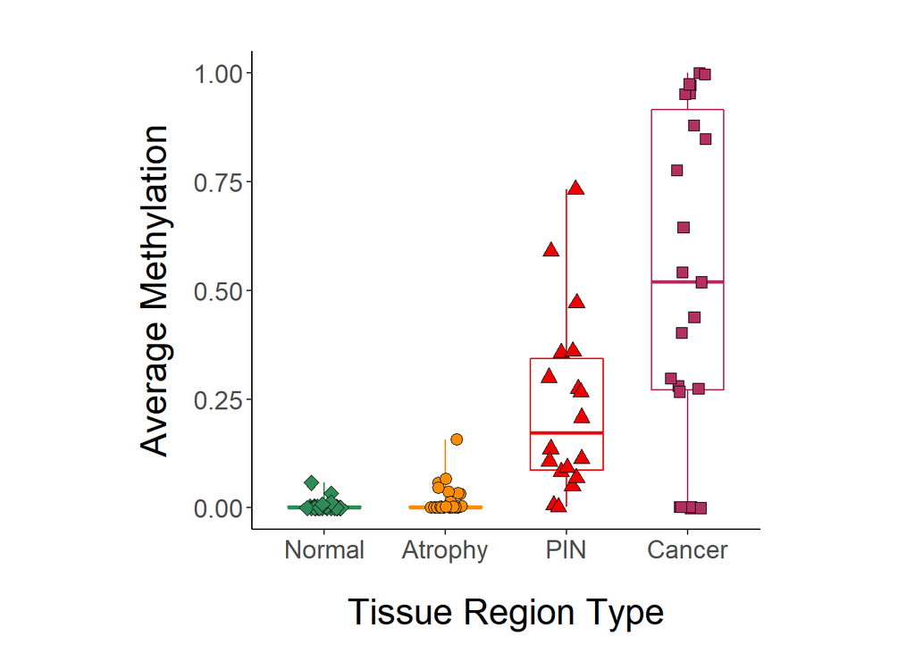

```r
#install.packages("ggplot2")
library("ggplot2")
library(RColorBrewer)

##Prepare a function to set the whiskers of a boxplot to the full range.

f <- function(x) {
  r <- quantile(x, probs = c(0, 0.25, 0.5, 0.75, 1))
  names(r) <- c("ymin", "lower", "middle", "upper", "ymax")
  r
}

## Create the stripchart and then do multiple formatting things.
## Format the order of x-axis, add custom labels, remove legend.
## Format the X- and Y-axis label font size and location, x- and y-axis tick label font size, and adjust the plot margins so everything is visible.

plotMeanMeth <- ggplot(MethSummaryData, aes(x=TissueType, y=MeanMeth)) +
  scale_x_discrete(name = "Tissue Region Type",      labels=c("Normal","Atrophy","PIN","Cancer"), limits=c("normal","atrophy","PIN","cancer")) +
  scale_y_continuous(name = "Average Methylation") +
  stat_summary(fun.data = f, geom="boxplot", aes(color=TissueType, width=0.6)) +
  geom_jitter(position=position_jitter(0.15), aes(shape=TissueType, fill=TissueType), colour="black", size=3, stroke=0.3) +
  theme_classic() +
  scale_shape_manual(values=c(21,22,23,24)) +
  scale_color_manual(values=c("darkorange","maroon","seagreen","red2")) +
  scale_fill_manual(values=c("darkorange","maroon","seagreen","red2")) +
  theme(legend.position="none") +
  theme(axis.title.x = element_text(size=20, vjust=-3), axis.title.y = element_text(size=20, vjust=3), axis.text.x = element_text(size=14), axis.text.y = element_text(size=14), plot.margin = unit(c(1,3,1,3), "cm"))
plotMeanMeth
```

```r
pdf("plotMeanMeth_Newest.pdf")
plotMeanMeth
dev.off()
```

Now that we have made a nice visualization of the data, it is clear that the MeanMeth is changing with the TissueType. We should test this hypothesis formally and assess the significance using Anova.

```r
aov(MeanMeth ~ TissueType, data = MethSummaryData)
```

```
## Call:
##    aov(formula = MeanMeth ~ TissueType, data = MethSummaryData)
##
## Terms:
##                 TissueType Residuals
## Sum of Squares    4.501847  3.910674
## Deg. of Freedom          3        98
##
## Residual standard error: 0.199762
## Estimated effects may be unbalanced
```

```r
summary(aov(MeanMeth ~ TissueType, data = MethSummaryData))
```

```
##             Df Sum Sq Mean Sq F value   Pr(>F)
## TissueType   3  4.502  1.5006    37.6 2.94e-16 ***
## Residuals   98  3.911  0.0399
## ---
## Signif. codes:  0 '***' 0.001 '**' 0.01 '*' 0.05 '.' 0.1 ' ' 1
```

```r
### Setting up individual contrasts of PIN vs. each of the other types.
MethSummaryData$TissueType = factor(MethSummaryData$TissueType, levels=c("normal","atrophy","PIN","cancer"))
PIN_normal = c(-1, 0, 1, 0)
PIN_atrophy = c(0, -1, 1, 0)
PIN_cancer = c(0, 0, 1, -1)
matriz = cbind(PIN_normal, PIN_atrophy, PIN_cancer)
contrasts(MethSummaryData$TissueType) <- matriz
CList = list("PIN-normal"=1, "PIN-atrophy"=2, "PIN-cancer"=3)
model1 <- aov(MeanMeth ~ TissueType, data = MethSummaryData)
summary.aov(model1, split=list(TissueType=CList))
```

```
##                           Df Sum Sq Mean Sq F value   Pr(>F)
## TissueType                 3  4.502   1.501   37.60 2.94e-16 ***
##   TissueType: PIN-normal   1  0.620   0.620   15.55 0.000151 ***
##   TissueType: PIN-atrophy  1  0.523   0.523   13.10 0.000470 ***
##   TissueType: PIN-cancer   1  3.359   3.359   84.17 7.50e-15 ***
## Residuals                 98  3.911   0.040
## ---
## Signif. codes:  0 '***' 0.001 '**' 0.01 '*' 0.05 '.' 0.1 ' ' 1
```

As expected the overall TissueType and contrasts for PIN vs. each of the other TissueTypes are all very significant.

To make sure this is not due to making a false assumption that the data are from a normal distribution, we can carry out non-parametric tests also:

```r
## PIN vs. normal
wilcox.test(MeanMeth ~ TissueType, data = MethSummaryData[MethSummaryData$TissueType==c("normal","PIN"), ]) #This is the mann-whitney U test
```

```
##
##  Wilcoxon rank sum test with continuity correction
##
## data:  MeanMeth by TissueType
## W = 9.5, p-value = 0.001753
## alternative hypothesis: true location shift is not equal to 0
```

```r
kruskal.test(MeanMeth ~ TissueType, data = MethSummaryData[MethSummaryData$TissueType==c("normal","PIN"), ]) #Kruskal Wallis test of one way anova by ranks
```

```
##
##  Kruskal-Wallis rank sum test
##
## data:  MeanMeth by TissueType
## Kruskal-Wallis chi-squared = 10.027, df = 1, p-value = 0.001543
```

```r
## PIN vs. Atrophy
wilcox.test(MeanMeth ~ TissueType, data = MethSummaryData[MethSummaryData$TissueType==c("atrophy","PIN"), ]) #This is the mann-whitney U test
```

```
##
##  Wilcoxon rank sum test with continuity correction
##
## data:  MeanMeth by TissueType
## W = 13, p-value = 0.0005384
## alternative hypothesis: true location shift is not equal to 0
```

```r
kruskal.test(MeanMeth ~ TissueType, data = MethSummaryData[MethSummaryData$TissueType==c("atrophy","PIN"), ]) #Kruskal Wallis test of one way anova by ranks
```

```
##
##  Kruskal-Wallis rank sum test
##
## data:  MeanMeth by TissueType
## Kruskal-Wallis chi-squared = 12.159, df = 1, p-value = 0.0004886
```

```r
## PIN vs. cancer
wilcox.test(MeanMeth ~ TissueType, data = MethSummaryData[MethSummaryData$TissueType==c("cancer","PIN"), ]) #This is the mann-whitney U test
```

```
##
##  Wilcoxon rank sum exact test
##
## data:  MeanMeth by TissueType
## W = 19, p-value = 0.1949
## alternative hypothesis: true location shift is not equal to 0
```

```r
kruskal.test(MeanMeth ~ TissueType, data = MethSummaryData[MethSummaryData$TissueType==c("cancer","PIN"), ]) #Kruskal Wallis test of one way anova by ranks
```

```
##
##  Kruskal-Wallis rank sum test
##
## data:  MeanMeth by TissueType
## Kruskal-Wallis chi-squared = 1.864, df = 1, p-value = 0.1722
```

Note that although cancer vs. pin was significant in the ANOVA test, it was not significant in the nonparametric tests.

Now we want to carry out various explorations of the average methylation data to see if there are other aspects to highlight before working on the phased methylation information.

First lets check if GSTP1 methylation is associated with Gleason Score in these data.

```r
## Summarize the GleasonScore spectrum in the cancer tissues
ddply(MethSummaryData[MethSummaryData$TissueType=="cancer",], c("TissueType","Comment"), summarise, N=length(Comment))

## Now Summarise by Gleason Sum
ddply(MethSummaryData[MethSummaryData$TissueType=="cancer",], c("TissueType","GleasonSum"), summarise, N=length(Comment))

## Plot MeanMeth by Gleason Score
ggplot(MethSummaryData[MethSummaryData$TissueType=="cancer",], aes(x=Comment, y=MeanMeth)) + geom_jitter(position=position_jitter(0.15), aes(colour=Comment))

## Plot MeanMeth by Gleason Sum
ggplot(MethSummaryData[MethSummaryData$TissueType=="cancer",], aes(x=GleasonSum, y=MeanMeth)) + geom_jitter(position=position_jitter(0.15), aes(colour=Comment))
```

[output not shown]

```r
## First set up a new vector that consolidates the Gleason sum into (GS > 6, "High") and (GS < 7, "Low").

cancerMethSummary <- MethSummaryData[MethSummaryData$TissueType=="cancer",]
cancerMethSummary$GleasonHiLow <- factor(cancerMethSummary$GleasonSum)
levels(cancerMethSummary$GleasonHiLow)
```

```
## [1] "5" "6" "7" "8"
```

```r
levels(cancerMethSummary$GleasonHiLow) <- c("Low", "Low", "High", "High")

#Now run a one-way Anova to test whether the means of MeanMeth is different between "High" and "Low"

aov(MeanMeth ~ GleasonHiLow, data = cancerMethSummary)
```

```
## Call:
##    aov(formula = MeanMeth ~ GleasonHiLow, data = cancerMethSummary)
##
## Terms:
##                 GleasonHiLow Residuals
## Sum of Squares     0.4140892 2.7424249
## Deg. of Freedom            1        21
##
## Residual standard error: 0.3613747
## Estimated effects may be unbalanced
```

```r
summary(aov(MeanMeth ~ GleasonHiLow, data = cancerMethSummary))
```

```
##              Df Sum Sq Mean Sq F value Pr(>F)
## GleasonHiLow  1 0.4141  0.4141   3.171 0.0894 .
## Residuals    21 2.7424  0.1306
## ---
## Signif. codes:  0 '***' 0.001 '**' 0.01 '*' 0.05 '.' 0.1 ' ' 1
```

Since the p-value, denoted by the column “Pr(>F)” is not significant, there is no association. We can also try a non-parametric test, such as the mann-whitney U test.

```r
wilcox.test(MeanMeth ~ GleasonHiLow, data = cancerMethSummary) #This is the mann-whitney U test
```

```
##
##  Wilcoxon rank sum test with continuity correction
##
## data:  MeanMeth by GleasonHiLow
## W = 31.5, p-value = 0.1087
## alternative hypothesis: true location shift is not equal to 0
```

```r
kruskal.test(MeanMeth ~ GleasonHiLow, data = cancerMethSummary) #Kruskal Wallis test of one way anova by ranks
```

```
##
##  Kruskal-Wallis rank sum test
##
## data:  MeanMeth by GleasonHiLow
## Kruskal-Wallis chi-squared = 2.681, df = 1, p-value = 0.1016
```

So no significant association with Grade.

Next, let’s check if PIN next to or merging with cancer have any association with mean methylation.

```r
## Turn the CAinSlide, NextTo and Merging vectors into factors in the dataframe.
MethSummaryData$CAinSlide <- factor(MethSummaryData$CAinSlide)
MethSummaryData$NextTo <- factor(MethSummaryData$NextTo)
MethSummaryData$Merging <- factor(MethSummaryData$Merging)
MethSummaryData$CAinSlide
MethSummaryData$NextTo
MethSummaryData$Merging

##The Merging has too many levels, probably worth consolidating so that CA = CA or CA_small or YES; PIN = Focal_HGPIN or HGPIN or LGPIN; NO = NO
levels(MethSummaryData$Merging) <- c("CA", "CA", "PIN", "PIN", "PIN", "NO", "CA")
MethSummaryData$Merging

## Summarize the PIN by CAinSlide, near or merging with cancer
ddply(MethSummaryData[MethSummaryData$TissueType=="PIN",], c("TissueType","CAinSlide","NextTo","Merging"), summarise, N=length(Merging))

## Make summary plots of these parameters and test associations
ggplot(MethSummaryData[MethSummaryData$TissueType=="PIN",], aes(x=Merging, y=MeanMeth)) + geom_jitter(position=position_jitter(0.15), aes(colour=Merging))

ggplot(MethSummaryData[MethSummaryData$TissueType=="PIN",], aes(x=NextTo, y=MeanMeth)) + geom_jitter(position=position_jitter(0.15), aes(colour=NextTo))

## The sample size for the previous two parameters seemed not very well distributed. May have more power if we just consider whether there was any cancer in the slide, which has a more even sample size across the two categories.
ggplot(MethSummaryData[MethSummaryData$TissueType=="PIN",], aes(x=CAinSlide, y=MeanMeth)) + geom_jitter(position=position_jitter(0.15), aes(colour=CAinSlide))
```

[output not shown]

```r
wilcox.test(MeanMeth ~ CAinSlide, data = MethSummaryData[MethSummaryData$TissueType=="PIN",]) #This is the mann-whitney U test
```

```
##
##  Wilcoxon rank sum exact test
##
## data:  MeanMeth by CAinSlide
## W = 22, p-value = 0.3359
## alternative hypothesis: true location shift is not equal to 0
```

```r
kruskal.test(MeanMeth ~ CAinSlide, data = MethSummaryData[MethSummaryData$TissueType=="PIN",]) #Kruskal Wallis test of one way anova by ranks
```

```
##
##  Kruskal-Wallis rank sum test
##
## data:  MeanMeth by CAinSlide
## Kruskal-Wallis chi-squared = 1.0713, df = 1, p-value = 0.3007
```

```r
aov(MeanMeth ~ CAinSlide, data = MethSummaryData[MethSummaryData$TissueType=="PIN",])
```

```
## Call:
##    aov(formula = MeanMeth ~ CAinSlide, data = MethSummaryData[MethSummaryData$TissueType ==
##     "PIN", ])
##
## Terms:
##                 CAinSlide Residuals
## Sum of Squares  0.0695635 0.6483516
## Deg. of Freedom         1        16
##
## Residual standard error: 0.2013007
## Estimated effects may be unbalanced
```

```r
summary(aov(MeanMeth ~ CAinSlide, data = MethSummaryData[MethSummaryData$TissueType=="PIN",]))
```

```
##             Df Sum Sq Mean Sq F value Pr(>F)
## CAinSlide    1 0.0696 0.06956   1.717  0.209
## Residuals   16 0.6484 0.04052
```

So it looks like this is not significant either. Perhaps it is worth noting that there is a trend for this in a supplementary figure.

8. Plot average methylation by each CpG across the four tissue types

Create CpG by CpG heatmap

Question: If a patient has two tissues, should those be 2 separate rows or a single row?

```r
library(ComplexHeatmap)
library(circlize)

# Summarize the Methylation Dataframe by averaging the methylation of clones for a given tissue.
CpGSummaryData <- methylationDataFrame %>%
  group_by(specimenID, TissueType, TissueDxNum) %>% # Group by patient, tissue type, and tissue ID
  select(starts_with("CpG_")) %>% # Select all the CpG columns
  summarise_all(mean, na.rm=TRUE)

# Reorder columns to be CpG_1 to CpG_39 rather than 39 to 1.
for (i in 39:1)
{
  CpGSummaryData <- CpGSummaryData %>%
    relocate(paste("CpG_",i,sep = ""), .after = TissueDxNum)
}

CpGSummaryData <- as.data.frame(CpGSummaryData)

CpGHeatmap <- CpGSummaryData %>%
  select(-c(specimenID,TissueDxNum, TissueType))
colnames(CpGHeatmap) <- gsub("CpG_","",colnames(CpGHeatmap))

# Users should always use circlize::colorRamp2() function to generate the color mapping function in Heatmap().

col_fun = colorRamp2(c(0,1), c("lightgray", "red"))

heatmap_plot <- Heatmap(CpGHeatmap,
        # Clustering
        cluster_columns = FALSE,
        cluster_row_slices = FALSE,

        # Split rows by tissue type
        row_split = factor(CpGSummaryData$TissueType,levels = c("normal", "atrophy", "PIN", "cancer")),

        # Dendograms
        show_row_dend = FALSE, show_column_dend = FALSE,

        # Titles
        name = "Average Methylation",
        row_title = c("Normal", "PIA", "PIN", "Cancer"),
        row_title_gp = gpar(fontsize = 15, fontface = "bold"),
        column_title = "CpG in GSTP1 Promoter", column_title_side = "bottom",
        column_title_gp = gpar(fontsize = 20, fontface = "bold"),
        column_names_gp = gpar(fontsize = 10),

        # Colors
        col = col_fun

        # Graphic parameters for grid

        )

heatmap_plot

pdf("../DNAMethylMap_Paper/heatmap.pdf")
heatmap_plot
dev.off()
```

[output not shown]

```r
##Plotting heat map

#create color palette from red to green
my_palette <- colorRampPalette(c("blue", "white", "red"))(n = 299)

## creates a 5 x 5 inch png image
pdf("../heatmap.pdf")    # create png for the heat map
  # width = 5*1000,        # 5 x 300 pixels
  # height = 5*1200,
  # res = 600,            # 600 pixels per inch
  # pointsize = 8)        # smaller font size

#par(mar=c(10,4,4,2))

heatmap.2(heatmap_norm,
  main = "RNA Seq of B6 vs EKO", # heat map title
  notecol="black",      # change font color of cell labels to black
  density.info="none",  # turns off density plot inside color legend
  trace="none",         # turns off trace lines inside the heat map
  margins =c(9,12),     # widens margins around plot
  col=my_palette,       # use on color palette defined earlier
  dendrogram="none",     # only draw a row dendrogram
  Colv="NA",             # turn off column clustering
  labRow = rownames(heatmap_norm),
  key.xlab = expression("z-score of log"[2]*"(TPM)"),
  cexCol = 1.5,
  cexRow = 0.40,
  keysize = 0.75
)
dev.off()
```

Boxplot code for reference – NOT USED